# Analisis Popularitas & Revenue Kategori Film

Database Sakila — MySQL | Tugas SIM CM 1

Alhena Sharliz Nur Fahmida | M0725057 | D

24 May 2026

# Pendahuluan

Database Sakila merupakan database simulasi rental film yang disediakan oleh MySQL. Database ini berisi berbagai informasi mengenai film, kategori film, pelanggan, pembayaran, dan transaksi penyewaan. Analisis dilakukan untuk mengetahui hubungan antara popularitas kategori film dengan revenue yang dihasilkan.

Pada penelitian ini digunakan metode visualisasi data dan regresi linear sederhana untuk melihat pengaruh jumlah rental terhadap total revenue kategori film.

Model regresi linear yang digunakan:

$$Y = \beta_0 + \beta_1 X +
\varepsilon$$

| Simbol | Keterangan |
| --- | --- |
| $Y$ | Total Revenue |
| $X$ | Jumlah Rental |
| $\beta_0$ | Intersep |
| $\beta_1$ | Koefisien Regresi |
| $\varepsilon$ | Error |

# Statistik Deskriptif

```r
summary(data_sakila)
```

```
##    kategori         jumlah_rental    total_revenue
##  Length:16          Min.   : 830.0   Min.   :3418
##  Class :character   1st Qu.: 939.8   1st Qu.:3706
##  Mode  :character   Median :1001.0   Median :4276
##                     Mean   :1002.8   Mean   :4213
##                     3rd Qu.:1097.2   3rd Qu.:4435
##                     Max.   :1179.0   Max.   :5314
```

# Total Revenue per Kategori

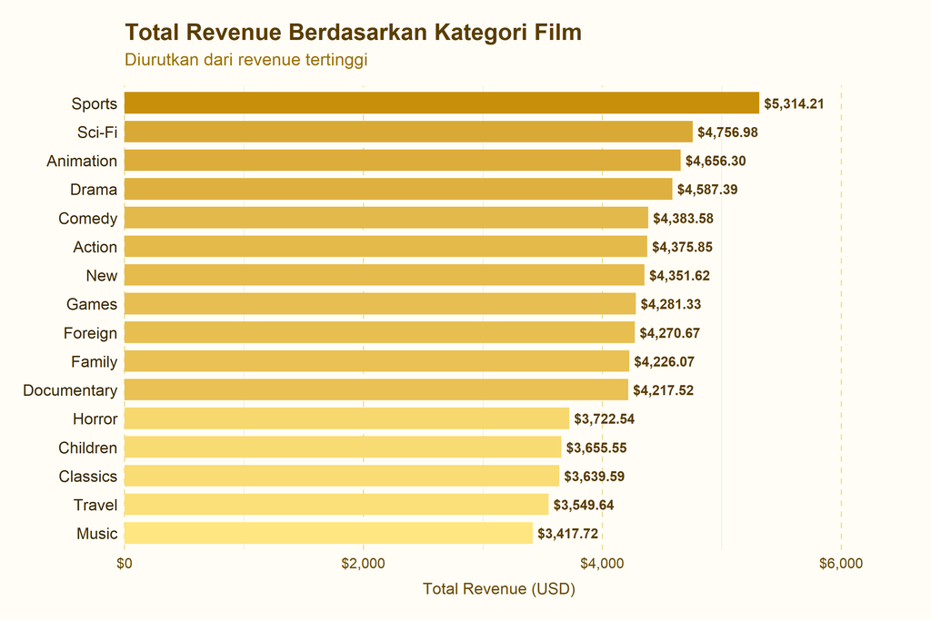

```r
ggplot(data_sakila,
       aes(x = reorder(kategori, total_revenue),
           y = total_revenue,
           fill = total_revenue)) +

  geom_bar(stat = "identity", width = 0.75, show.legend = FALSE) +

  geom_text(aes(label = dollar(total_revenue, prefix = "$")),
            hjust = -0.08, size = 3.4, color = "#5a3e00", fontface = "bold") +

  scale_fill_gradient(low = "#fFe680", high = "#c8900a") +

  coord_flip(clip = "off") +

  scale_y_continuous(labels = dollar_format(), expand = expansion(mult = c(0, 0.18))) +

  labs(
    title    = "Total Revenue Berdasarkan Kategori Film",
    subtitle = "Diurutkan dari revenue tertinggi",
    x        = NULL,
    y        = "Total Revenue (USD)"
  ) +

  theme_minimal(base_family = "sans") +

  theme(
    plot.title       = element_text(size = 16, face = "bold",  color = "#5a3e00"),
    plot.subtitle    = element_text(size = 12, color = "#9a7000", margin = margin(b = 12)),
    axis.text.y      = element_text(size = 11, color = "#3c2a00"),
    axis.text.x      = element_text(size = 10, color = "#6b4c00"),
    axis.title.x     = element_text(size = 11, color = "#6b4c00", margin = margin(t = 8)),
    panel.grid.major.y = element_blank(),
    panel.grid.major.x = element_line(color = "#f0e0a0", linetype = "dashed"),
    plot.background  = element_rect(fill = "#fffdf5", color = NA),
    panel.background = element_rect(fill = "#fffdf5", color = NA),
    plot.margin      = margin(16, 40, 16, 16)
  )
```

# Jumlah Rental per Kategori

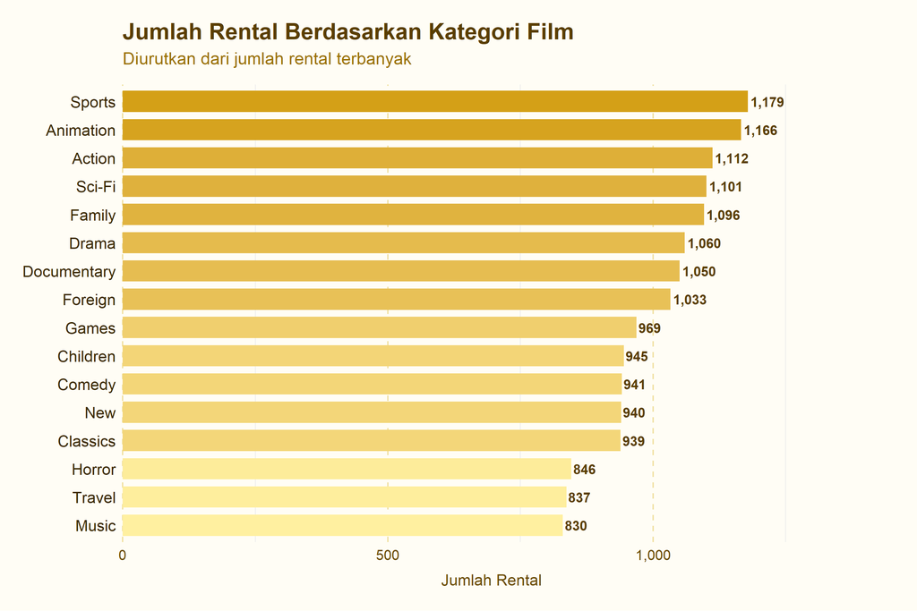

```r
ggplot(data_sakila,
       aes(x = reorder(kategori, jumlah_rental),
           y = jumlah_rental,
           fill = jumlah_rental)) +

  geom_bar(stat = "identity", width = 0.75, show.legend = FALSE) +

  geom_text(aes(label = comma(jumlah_rental)),
            hjust = -0.08, size = 3.4, color = "#5a3e00", fontface = "bold") +

  scale_fill_gradient(low = "#fff0a0", high = "#d4a017") +

  coord_flip(clip = "off") +

  scale_y_continuous(labels = comma, expand = expansion(mult = c(0, 0.18))) +

  labs(
    title    = "Jumlah Rental Berdasarkan Kategori Film",
    subtitle = "Diurutkan dari jumlah rental terbanyak",
    x        = NULL,
    y        = "Jumlah Rental"
  ) +

  theme_minimal(base_family = "sans") +

  theme(
    plot.title       = element_text(size = 16, face = "bold",  color = "#5a3e00"),
    plot.subtitle    = element_text(size = 12, color = "#9a7000", margin = margin(b = 12)),
    axis.text.y      = element_text(size = 11, color = "#3c2a00"),
    axis.text.x      = element_text(size = 10, color = "#6b4c00"),
    axis.title.x     = element_text(size = 11, color = "#6b4c00", margin = margin(t = 8)),
    panel.grid.major.y = element_blank(),
    panel.grid.major.x = element_line(color = "#f0e0a0", linetype = "dashed"),
    plot.background  = element_rect(fill = "#fffdf5", color = NA),
    panel.background = element_rect(fill = "#fffdf5", color = NA),
    plot.margin      = margin(16, 40, 16, 16)
  )
```

# Analisis Regresi Linear

```r
model_regresi <- lm(total_revenue ~ jumlah_rental, data = data_sakila)
summary(model_regresi)
```

```
##
## Call:
## lm(formula = total_revenue ~ jumlah_rental, data = data_sakila)
##
## Residuals:
##     Min      1Q  Median      3Q     Max
## -342.09 -197.21  -44.65  176.58  429.85
##
## Coefficients:
##               Estimate Std. Error t value Pr(>|t|)
## (Intercept)   392.8032   640.0757   0.614    0.549
## jumlah_rental   3.8096     0.6345   6.004 3.23e-05 ***
## ---
## Signif. codes:  0 '***' 0.001 '**' 0.01 '*' 0.05 '.' 0.1 ' ' 1
##
## Residual standard error: 278.5 on 14 degrees of freedom
## Multiple R-squared:  0.7203, Adjusted R-squared:  0.7003
## F-statistic: 36.05 on 1 and 14 DF,  p-value: 3.233e-05
```

# Visualisasi Regresi

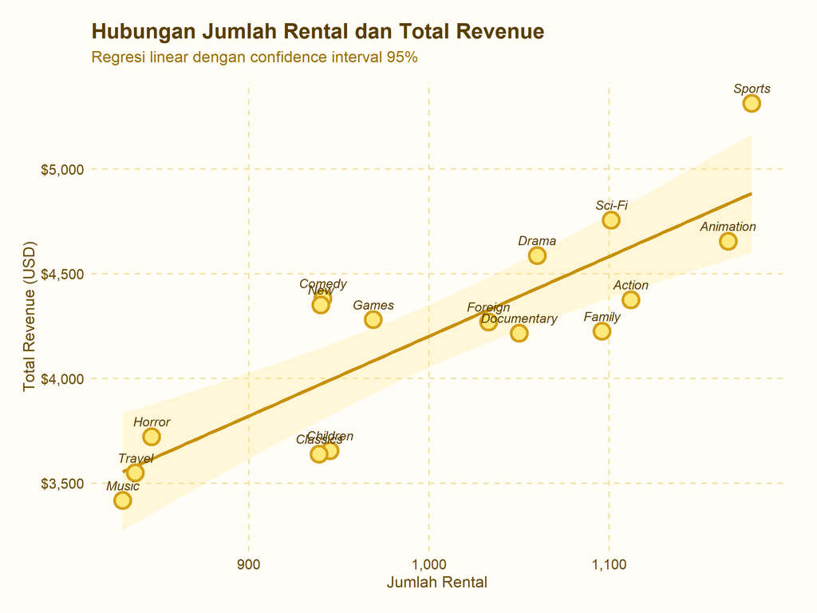

```r
ggplot(data_sakila,
       aes(x = jumlah_rental, y = total_revenue)) +

  geom_smooth(method = "lm", se = TRUE,
              color = "#c8900a", fill = "#ffe680", alpha = 0.25, linewidth = 1.2) +

  geom_point(size = 4.5, color = "#d4a017",
             shape = 21, fill = "#ffe97a", stroke = 1.5) +

  geom_text(aes(label = kategori),
            vjust = -1.1, size = 3.2, color = "#5a3e00", fontface = "italic") +

  scale_x_continuous(labels = comma) +
  scale_y_continuous(labels = dollar_format()) +

  labs(
    title    = "Hubungan Jumlah Rental dan Total Revenue",
    subtitle = "Regresi linear dengan confidence interval 95%",
    x        = "Jumlah Rental",
    y        = "Total Revenue (USD)"
  ) +

  theme_minimal(base_family = "sans") +

  theme(
    plot.title       = element_text(size = 15, face = "bold",  color = "#5a3e00"),
    plot.subtitle    = element_text(size = 11, color = "#9a7000", margin = margin(b = 12)),
    axis.text        = element_text(size = 10, color = "#6b4c00"),
    axis.title       = element_text(size = 11, color = "#6b4c00"),
    panel.grid.minor = element_blank(),
    panel.grid.major = element_line(color = "#f0e0a0", linetype = "dashed"),
    plot.background  = element_rect(fill = "#fffdf5", color = NA),
    panel.background = element_rect(fill = "#fffdf5", color = NA),
    plot.margin      = margin(16, 24, 16, 16)
  )
```

# Korelasi Data

```r
r <- cor(data_sakila$jumlah_rental, data_sakila$total_revenue)
cat(sprintf("Koefisien Korelasi Pearson: %.4f\n", r))
```

```
## Koefisien Korelasi Pearson: 0.8487
```

# Interpretasi Visualisasi

Visualisasi total revenue per kategori film memperlihatkan adanya perbedaan pendapatan yang cukup signifikan antar kategori. Beberapa kategori memiliki revenue yang jauh lebih tinggi dibanding kategori lainnya, yang menunjukkan bahwa kategori tersebut lebih diminati oleh pelanggan. Diagram batang yang diurutkan dari revenue tertinggi juga mempermudah dalam mengidentifikasi kategori film yang memberikan kontribusi terbesar terhadap pendapatan perusahaan.

Visualisasi jumlah rental per kategori menunjukkan pola yang hampir serupa dengan grafik revenue. Kategori dengan jumlah rental tinggi umumnya juga memiliki total revenue yang tinggi. Hal ini memperkuat dugaan adanya hubungan positif antara kedua variabel tersebut.

Pada visualisasi regresi linear, titik-titik data membentuk pola yang cenderung naik mengikuti garis regresi. Pola ini menunjukkan bahwa semakin besar jumlah rental, maka total revenue juga meningkat. Garis regresi yang menanjak memperlihatkan hubungan linear positif, sedangkan confidence interval yang relatif sempit menunjukkan bahwa model regresi cukup baik dalam merepresentasikan hubungan antar variabel.

# Interpretasi Hasil

Berdasarkan hasil analisis yang telah dilakukan, diperoleh beberapa temuan utama:

> **Variasi Revenue Antar Kategori** — Terdapat perbedaan revenue yang cukup signifikan antar kategori film, mengindikasikan bahwa preferensi pelanggan bervariasi secara nyata.

> **Hubungan Positif** — Hasil regresi linear menunjukkan hubungan positif antara jumlah rental dan total revenue. Semakin tinggi penyewaan suatu kategori, semakin besar pendapatan yang dihasilkan.

> **Korelasi Kuat** — Nilai koefisien korelasi yang mendekati 1 menandakan hubungan linear yang sangat kuat antara kedua variabel.

Berdasarkan hasil analisis data pada database Sakila, diketahui bahwa setiap kategori film memiliki tingkat popularitas dan total revenue yang berbeda-beda. Perbedaan ini menunjukkan bahwa minat pelanggan terhadap kategori film tidak merata. Kategori dengan jumlah rental yang lebih tinggi cenderung menghasilkan revenue yang lebih besar dibandingkan kategori lainnya. Hal ini menandakan bahwa tingkat penyewaan film memiliki pengaruh terhadap pendapatan yang diperoleh perusahaan rental film.

Hasil regresi linear sederhana menunjukkan adanya hubungan positif antara variabel jumlah rental dan total revenue. Artinya, setiap peningkatan jumlah penyewaan film akan diikuti oleh peningkatan total pendapatan. Dari hasil model regresi yang diperoleh, jumlah rental dapat digunakan sebagai prediktor yang cukup baik dalam memperkirakan revenue suatu kategori film.

Selain itu, nilai koefisien korelasi Pearson yang mendekati angka 1 menunjukkan hubungan linear yang sangat kuat antara jumlah rental dan total revenue. Dengan demikian, dapat disimpulkan bahwa popularitas kategori film berkontribusi besar terhadap peningkatan pendapatan bisnis rental film.

# Kesimpulan

Metode visualisasi data dan regresi linear terbukti efektif dalam mengungkap pola hubungan antar variabel dan dapat dijadikan dasar pengambilan keputusan bisnis — misalnya dalam memprioritaskan pengadaan stok film pada kategori-kategori dengan permintaan tinggi.

# Penutup

Analisis telah selesai dilakukan. Seluruh data diambil dari database sakila dari mySQL dan koneksi telah ditutup :).